# IODS course project

# Clustering and classification

We will use the data on housing values in suburbs of Boston from D. Harrison and D.L. Rubenfeld (1978), “Hedonic Prices and the Demand for Clean Air,” Journal of Environmental Economics and Management 5, 81–102. These data are contained in the MASS package, and add-on library. This data frame contains 506 obs. of 14 variables.

```r
##### Access all the required libraries for the exercise
library(dplyr)
library(ggplot2)
library(tidyr)
library(corrplot)
library(reshape2)
library(plotly)
```

#### 2. Load and explore the data

```r
library(MASS)
data("Boston")
dim(Boston)
```

```
## [1] 506  14
```

```r
str(Boston)
```

```
## 'data.frame':    506 obs. of  14 variables:
##  $ crim   : num  0.00632 0.02731 0.02729 0.03237 0.06905 ...
##  $ zn     : num  18 0 0 0 0 0 12.5 12.5 12.5 12.5 ...
##  $ indus  : num  2.31 7.07 7.07 2.18 2.18 2.18 7.87 7.87 7.87 7.87 ...
##  $ chas   : int  0 0 0 0 0 0 0 0 0 0 ...
##  $ nox    : num  0.538 0.469 0.469 0.458 0.458 0.458 0.524 0.524 0.524 0.524 ...
##  $ rm     : num  6.58 6.42 7.18 7 7.15 ...
##  $ age    : num  65.2 78.9 61.1 45.8 54.2 58.7 66.6 96.1 100 85.9 ...
##  $ dis    : num  4.09 4.97 4.97 6.06 6.06 ...
##  $ rad    : int  1 2 2 3 3 3 5 5 5 5 ...
##  $ tax    : num  296 242 242 222 222 222 311 311 311 311 ...
##  $ ptratio: num  15.3 17.8 17.8 18.7 18.7 18.7 15.2 15.2 15.2 15.2 ...
##  $ black  : num  397 397 393 395 397 ...
##  $ lstat  : num  4.98 9.14 4.03 2.94 5.33 ...
##  $ medv   : num  24 21.6 34.7 33.4 36.2 28.7 22.9 27.1 16.5 18.9 ...
```

*This data tells about the housing values in sururbs of Boston.*

*It has 506 entries and 14 variables.*

#### 3. Summary of variables and Graphical overview of the data.

##### Summary of variables in the data

```r
summary(Boston)
```

```
##       crim                zn             indus            chas
##  Min.   : 0.00632   Min.   :  0.00   Min.   : 0.46   Min.   :0.00000
##  1st Qu.: 0.08204   1st Qu.:  0.00   1st Qu.: 5.19   1st Qu.:0.00000
##  Median : 0.25651   Median :  0.00   Median : 9.69   Median :0.00000
##  Mean   : 3.61352   Mean   : 11.36   Mean   :11.14   Mean   :0.06917
##  3rd Qu.: 3.67708   3rd Qu.: 12.50   3rd Qu.:18.10   3rd Qu.:0.00000
##  Max.   :88.97620   Max.   :100.00   Max.   :27.74   Max.   :1.00000
##       nox               rm             age              dis
##  Min.   :0.3850   Min.   :3.561   Min.   :  2.90   Min.   : 1.130
##  1st Qu.:0.4490   1st Qu.:5.886   1st Qu.: 45.02   1st Qu.: 2.100
##  Median :0.5380   Median :6.208   Median : 77.50   Median : 3.207
##  Mean   :0.5547   Mean   :6.285   Mean   : 68.57   Mean   : 3.795
##  3rd Qu.:0.6240   3rd Qu.:6.623   3rd Qu.: 94.08   3rd Qu.: 5.188
##  Max.   :0.8710   Max.   :8.780   Max.   :100.00   Max.   :12.127
##       rad              tax           ptratio          black
##  Min.   : 1.000   Min.   :187.0   Min.   :12.60   Min.   :  0.32
##  1st Qu.: 4.000   1st Qu.:279.0   1st Qu.:17.40   1st Qu.:375.38
##  Median : 5.000   Median :330.0   Median :19.05   Median :391.44
##  Mean   : 9.549   Mean   :408.2   Mean   :18.46   Mean   :356.67
##  3rd Qu.:24.000   3rd Qu.:666.0   3rd Qu.:20.20   3rd Qu.:396.23
##  Max.   :24.000   Max.   :711.0   Max.   :22.00   Max.   :396.90
##      lstat            medv
##  Min.   : 1.73   Min.   : 5.00
##  1st Qu.: 6.95   1st Qu.:17.02
##  Median :11.36   Median :21.20
##  Mean   :12.65   Mean   :22.53
##  3rd Qu.:16.95   3rd Qu.:25.00
##  Max.   :37.97   Max.   :50.00
```

##### Graphical overview

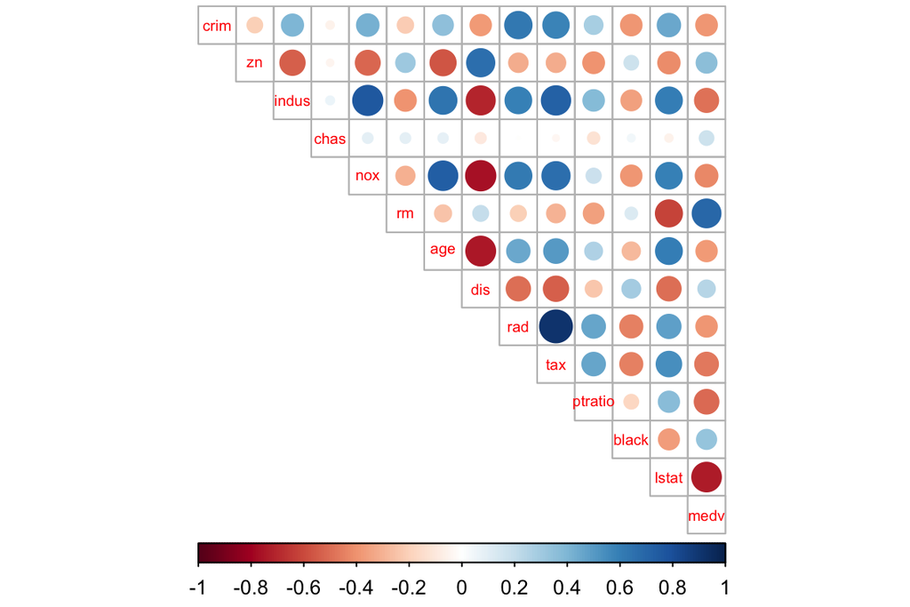

```r
cor_matrix<-cor(Boston)
library(corrplot)
corrplot(cor_matrix, method="circle", type = "upper", cl.pos = "b", tl.pos = "d", tl.cex = 0.6)
```

*From the correaltion matrix the findings are:* *1. rad is highly positively correlated with tax.* *2. dis is negatively correlated with index, nox and age.* *3. lstat is negatively correlated with medv*

##### Explanation of 14 variables

crim = per capita crime rate by town zn = proportion of residential land zoned for lots over 25,000 sq.ft indus = proportion of non-retail business acres per town chas = Charles River dummy variable (= 1 if tract bounds river; 0 otherwise) nox = nitrogen oxides concentration (parts per 10 million) rm = average number of rooms per dwelling age = proportion of owner-occupied units built prior to 1940 dis = weighted mean of distances to five Boston employment centres rad = index of accessibility to radial highways tax = full-value property-tax rate per $10,000 ptratio = pupil-teacher ratio by town black = 1000(Bk - 0.63)^2 where Bk is the proportion of blacks by town lstat = lower status of the population (percent) medv = median value of owner-occupied homes in $1000s

##### Distribution of 14 variables

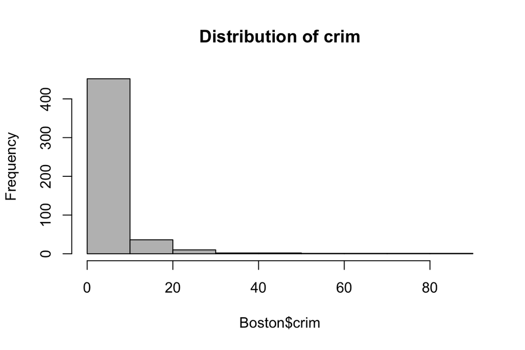

```r
hist(Boston$crim, col = "grey", main = "Distribution of crim")
```

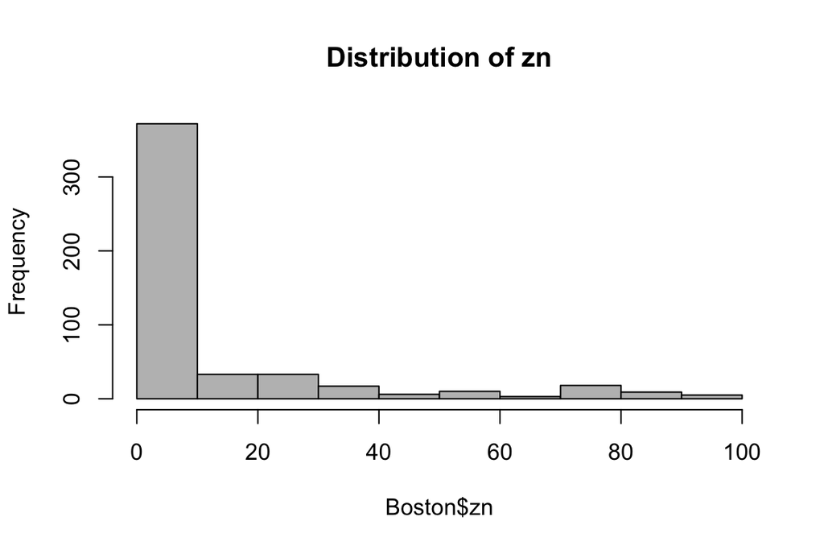

```r
hist(Boston$zn, col = "grey", main = "Distribution of zn")
```

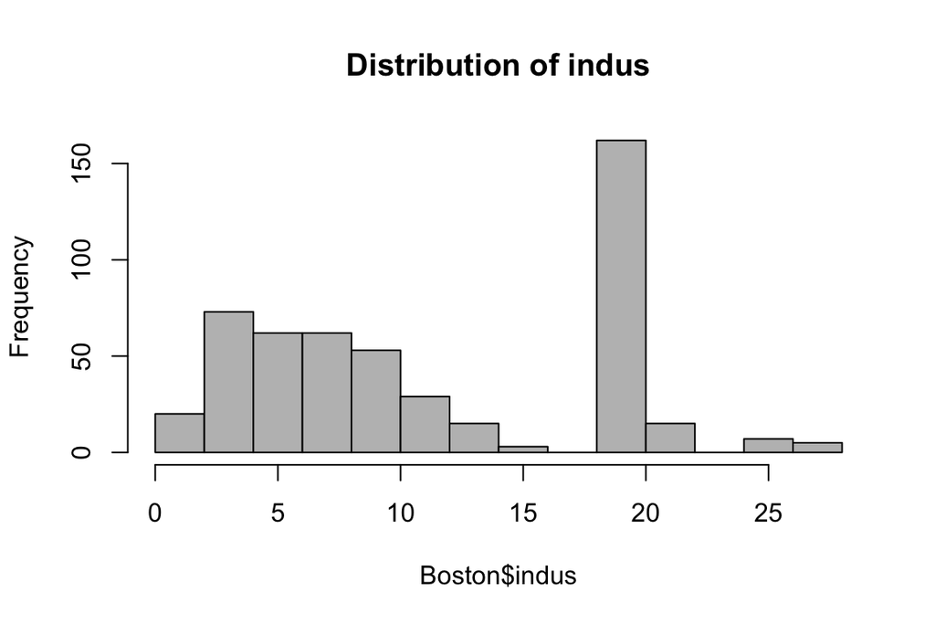

```r
hist(Boston$indus, col = "grey", main = "Distribution of indus")
```

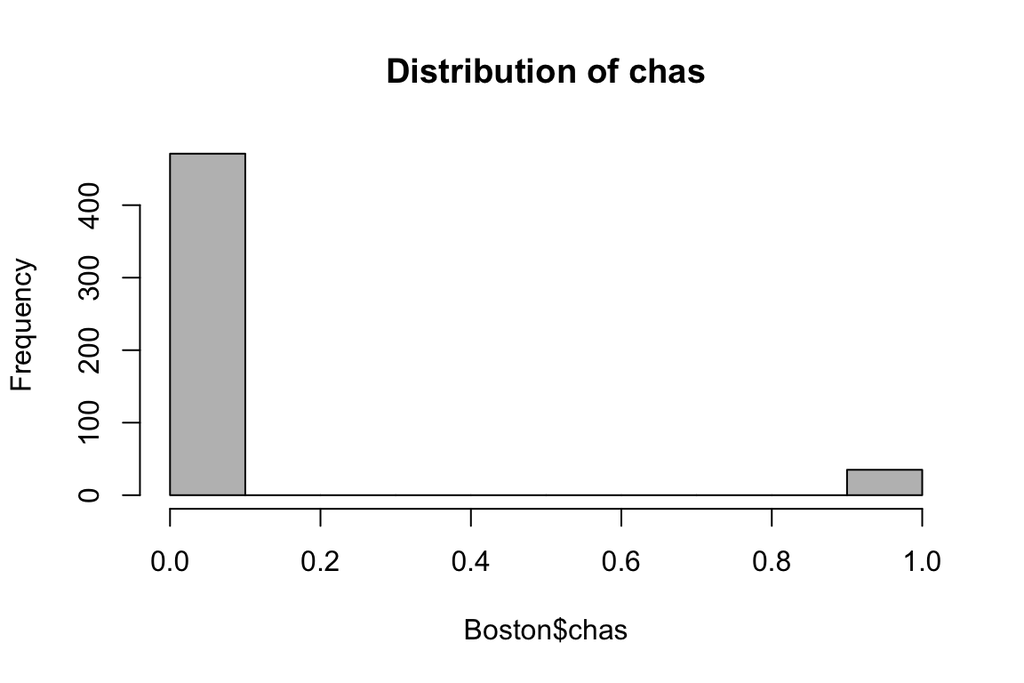

```r
hist(Boston$chas, col = "grey", main = "Distribution of chas")
```

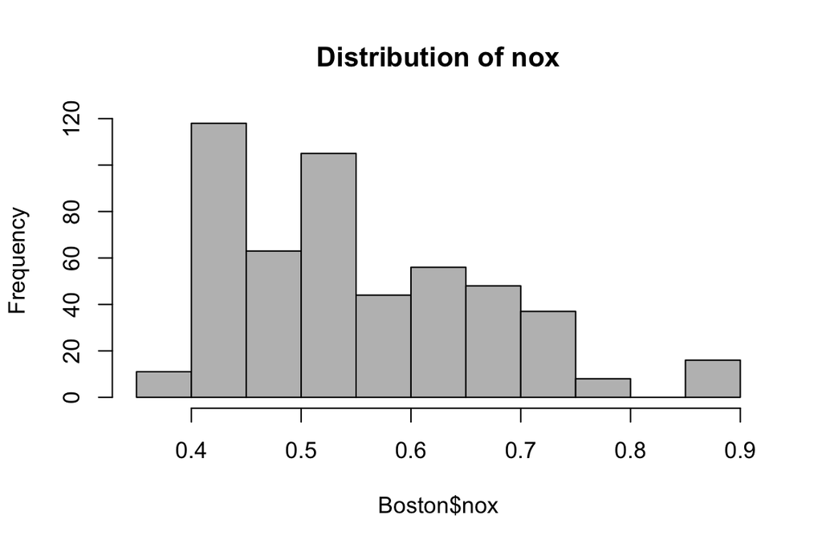

```r
hist(Boston$nox, col = "grey", main = "Distribution of nox")
```

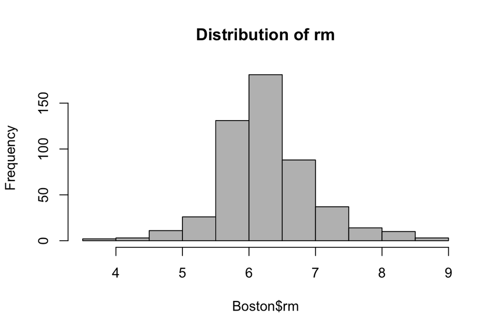

```r
hist(Boston$rm, col = "grey", main = "Distribution of rm")
```

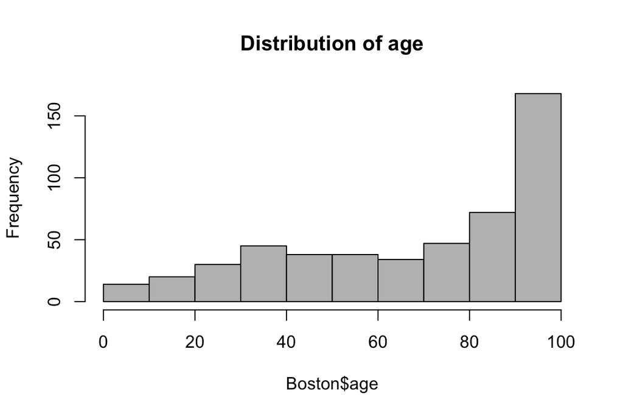

```r
hist(Boston$age, col = "grey", main = "Distribution of age")
```

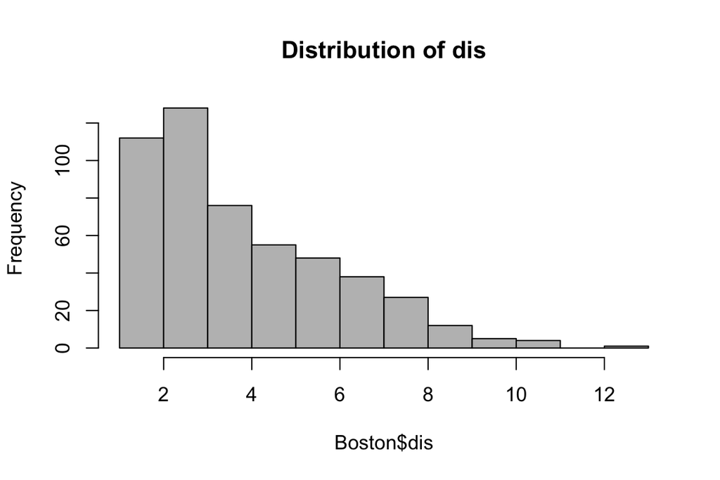

```r
hist(Boston$dis, col = "grey", main = "Distribution of dis")
```

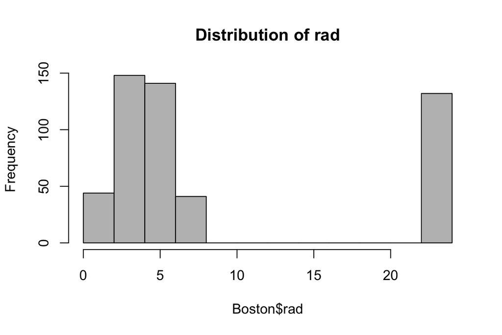

```r
hist(Boston$rad, col = "grey", main = "Distribution of rad")
```

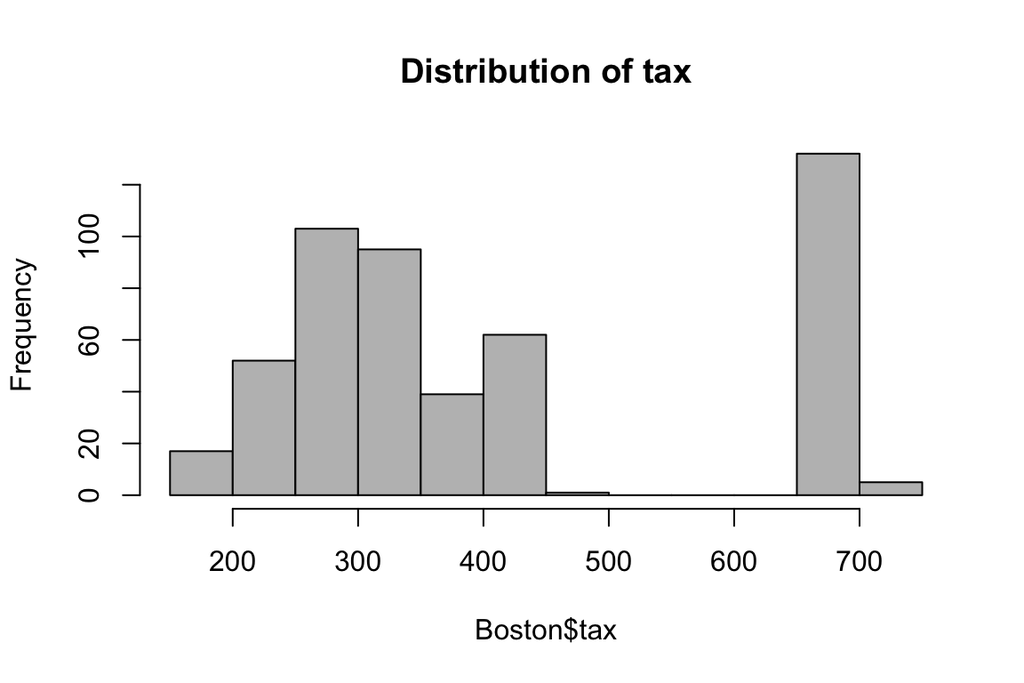

```r
hist(Boston$tax, col = "grey", main = "Distribution of tax")
```

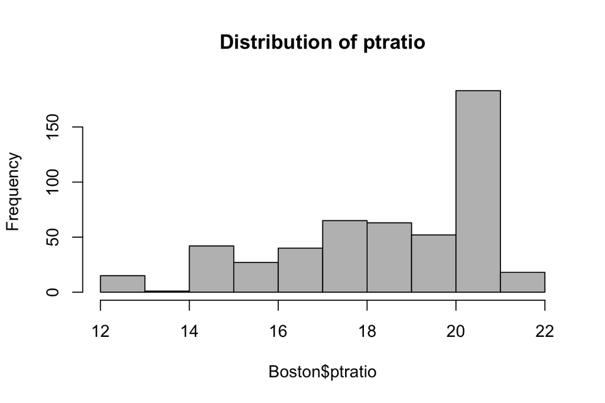

```r
hist(Boston$ptratio, col = "grey", main = "Distribution of ptratio")
```

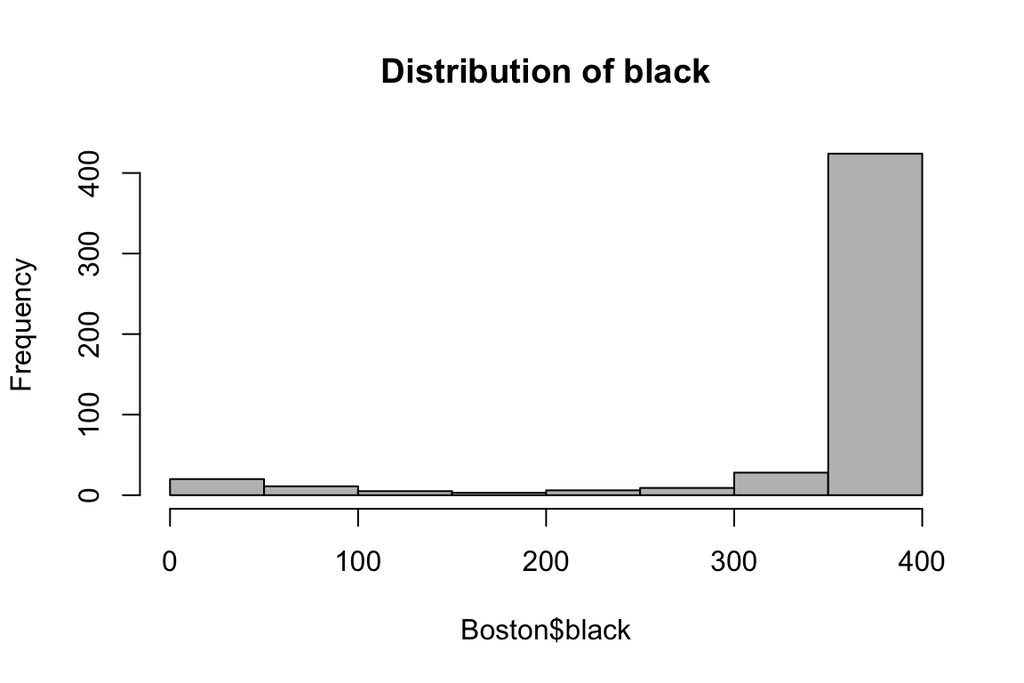

```r
hist(Boston$black, col = "grey", main = "Distribution of black")
```

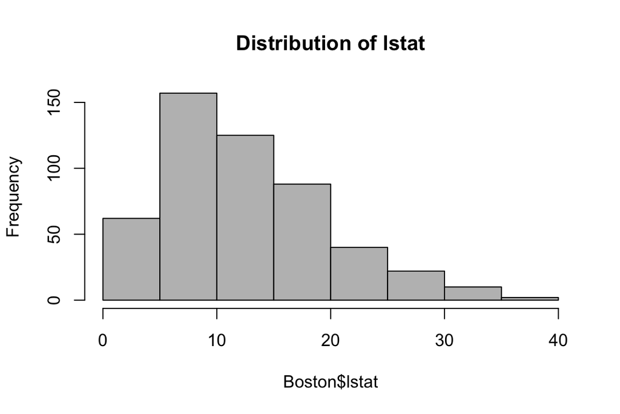

```r
hist(Boston$lstat, col = "grey", main = "Distribution of lstat")
```

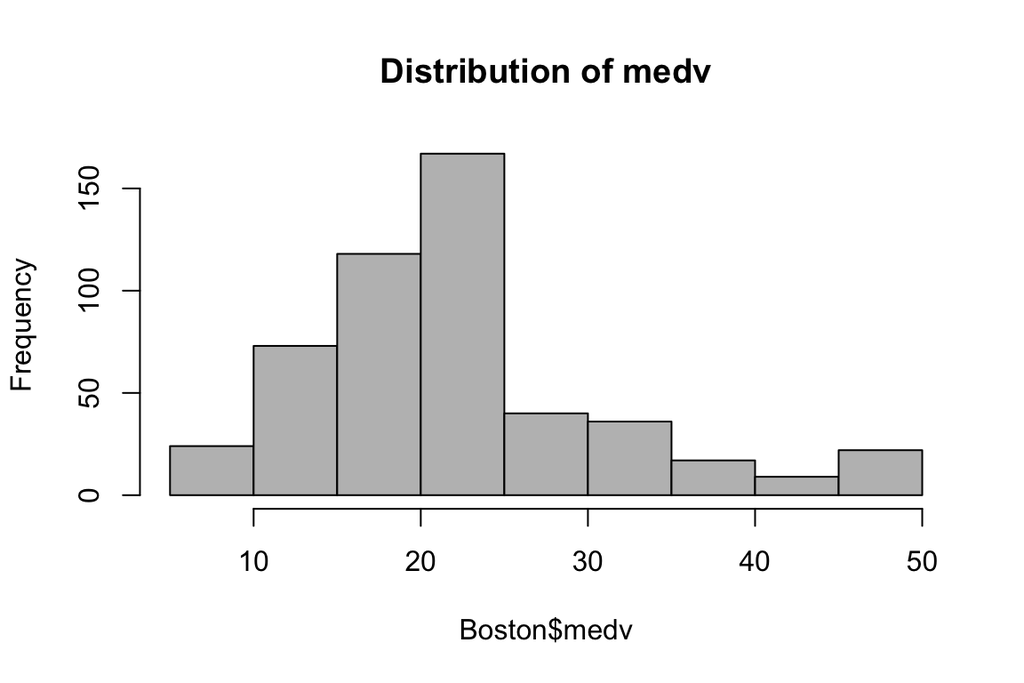

```r
hist(Boston$medv, col = "grey", main = "Distribution of medv")
```

*The variables that follow normal distribution are rm and medv. It can be also seen from summary for these variables as mean and median are closer.*

#### 4. Standardize the data

```r
##### Scale the variables
boston_scaled <- scale(Boston)


##### Summaries of the scaled variables
summary(boston_scaled)
```

```
##       crim                 zn               indus
##  Min.   :-0.419367   Min.   :-0.48724   Min.   :-1.5563
##  1st Qu.:-0.410563   1st Qu.:-0.48724   1st Qu.:-0.8668
##  Median :-0.390280   Median :-0.48724   Median :-0.2109
##  Mean   : 0.000000   Mean   : 0.00000   Mean   : 0.0000
##  3rd Qu.: 0.007389   3rd Qu.: 0.04872   3rd Qu.: 1.0150
##  Max.   : 9.924110   Max.   : 3.80047   Max.   : 2.4202
##       chas              nox                rm               age
##  Min.   :-0.2723   Min.   :-1.4644   Min.   :-3.8764   Min.   :-2.3331
##  1st Qu.:-0.2723   1st Qu.:-0.9121   1st Qu.:-0.5681   1st Qu.:-0.8366
##  Median :-0.2723   Median :-0.1441   Median :-0.1084   Median : 0.3171
##  Mean   : 0.0000   Mean   : 0.0000   Mean   : 0.0000   Mean   : 0.0000
##  3rd Qu.:-0.2723   3rd Qu.: 0.5981   3rd Qu.: 0.4823   3rd Qu.: 0.9059
##  Max.   : 3.6648   Max.   : 2.7296   Max.   : 3.5515   Max.   : 1.1164
##       dis               rad               tax             ptratio
##  Min.   :-1.2658   Min.   :-0.9819   Min.   :-1.3127   Min.   :-2.7047
##  1st Qu.:-0.8049   1st Qu.:-0.6373   1st Qu.:-0.7668   1st Qu.:-0.4876
##  Median :-0.2790   Median :-0.5225   Median :-0.4642   Median : 0.2746
##  Mean   : 0.0000   Mean   : 0.0000   Mean   : 0.0000   Mean   : 0.0000
##  3rd Qu.: 0.6617   3rd Qu.: 1.6596   3rd Qu.: 1.5294   3rd Qu.: 0.8058
##  Max.   : 3.9566   Max.   : 1.6596   Max.   : 1.7964   Max.   : 1.6372
##      black             lstat              medv
##  Min.   :-3.9033   Min.   :-1.5296   Min.   :-1.9063
##  1st Qu.: 0.2049   1st Qu.:-0.7986   1st Qu.:-0.5989
##  Median : 0.3808   Median :-0.1811   Median :-0.1449
##  Mean   : 0.0000   Mean   : 0.0000   Mean   : 0.0000
##  3rd Qu.: 0.4332   3rd Qu.: 0.6024   3rd Qu.: 0.2683
##  Max.   : 0.4406   Max.   : 3.5453   Max.   : 2.9865
```

```r
##### Crime rate from scaled Boston dataset
#### change the object to data frame
boston_scaled <- as.data.frame(boston_scaled)
scaled_crim <- boston_scaled$crim
summary(scaled_crim)
```

```
##      Min.   1st Qu.    Median      Mean   3rd Qu.      Max.
## -0.419400 -0.410600 -0.390300  0.000000  0.007389  9.924000
```

```r
##### create a quantile vector of crim
bins <- quantile(scaled_crim)
bins
```

```
##           0%          25%          50%          75%         100%
## -0.419366929 -0.410563278 -0.390280295  0.007389247  9.924109610
```

```r
##### Create a categorical variable 'crime'
crime <- cut(scaled_crim, breaks = bins, include.lowest = TRUE, label = c("low", "med_low", "med_high", "high"))

##### Remove original crim from the dataset
boston_scaled <- dplyr::select(boston_scaled, -crim)

##### Add the new categorical value to scaled data
boston_scaled <- data.frame(boston_scaled, crime)

##### Creatde test and training data
n <- nrow(boston_scaled)
ind <- sample(n,  size = n * 0.8)
train <- boston_scaled[ind,]
test <- boston_scaled[-ind,]
```

#### 5. LDA

```r
##### linear discriminant analysis
##### Using the categorical crime rate as the target variable and all the other variables in the dataset as predictor variables.
lda.fit <- lda(crime ~ ., data = train)
lda.fit
```

```
## Call:
## lda(crime ~ ., data = train)
##
## Prior probabilities of groups:
##       low   med_low  med_high      high
## 0.2549505 0.2475248 0.2425743 0.2549505
##
## Group means:
##                  zn       indus         chas        nox          rm
## low       0.9990978 -0.92869094 -0.157656245 -0.8784532  0.41934282
## med_low  -0.1442231 -0.30196386  0.003267949 -0.5487343 -0.13066061
## med_high -0.3629840  0.09969394  0.169590347  0.3479993  0.07586548
## high     -0.4872402  1.01708911 -0.042983423  1.0552146 -0.41769412
##                 age        dis        rad        tax     ptratio
## low      -0.8849674  0.9262802 -0.6875068 -0.7591556 -0.45616503
## med_low  -0.2566321  0.3082857 -0.5488991 -0.5173766 -0.06768466
## med_high  0.3969275 -0.3367388 -0.4240444 -0.3489960 -0.27828523
## high      0.8153894 -0.8587874  1.6384176  1.5142626  0.78111358
##               black       lstat        medv
## low       0.3753510 -0.76190777  0.51063029
## med_low   0.3177733 -0.09447660 -0.01422256
## med_high  0.1026551  0.02210527  0.15065188
## high     -0.7199339  0.92592430 -0.70186619
##
## Coefficients of linear discriminants:
##                 LD1          LD2          LD3
## zn       0.09253934  0.816881540 -0.852425608
## indus    0.04072215 -0.194474094  0.281712240
## chas    -0.03081866 -0.061860188  0.088919177
## nox      0.42011175 -0.627707802 -1.588565514
## rm       0.05725993 -0.109175449 -0.136615796
## age      0.27804181 -0.334969077 -0.154391541
## dis     -0.02393428 -0.244540114 -0.003422173
## rad      3.29856825  1.025315897  0.143051122
## tax      0.10317066 -0.165017214  0.393608096
## ptratio  0.12406957  0.014863570 -0.297883528
## black   -0.07580536  0.003729292  0.112825452
## lstat    0.14203927 -0.216400026  0.430191781
## medv     0.04206340 -0.369083074 -0.210548552
##
## Proportion of trace:
##    LD1    LD2    LD3
## 0.9541 0.0339 0.0120
```

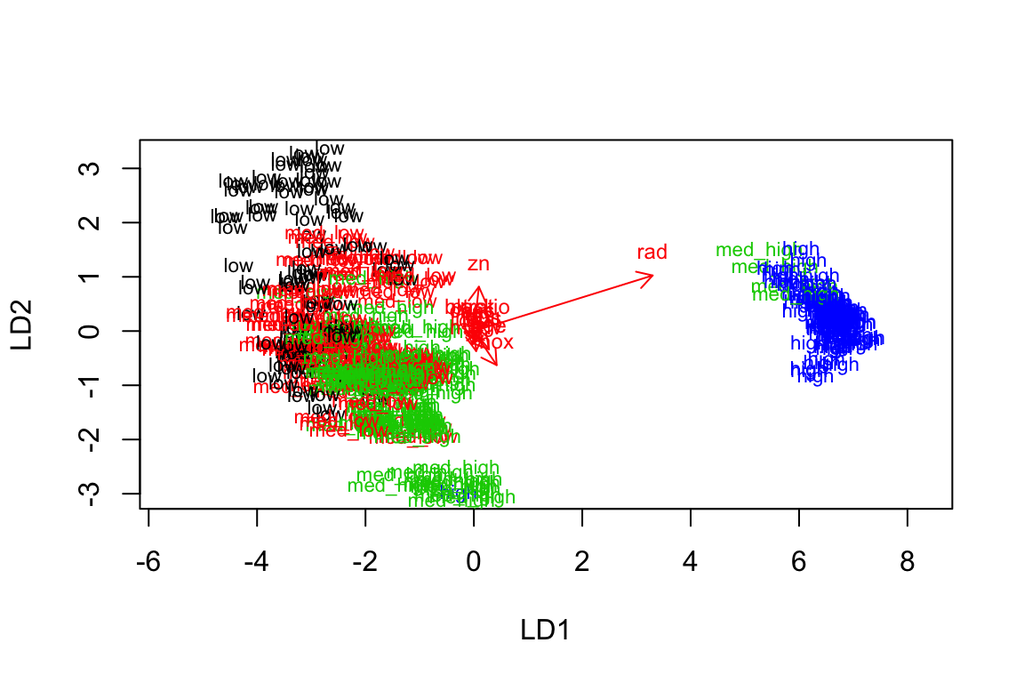

```r
##### biplot
lda.arrows <- function(x, myscale = 1, arrow_heads = 0.1, color = "red", tex = 0.75, choices = c(1,2)){
  heads <- coef(x)
  arrows(x0 = 0, y0 = 0,
         x1 = myscale * heads[,choices[1]],
         y1 = myscale * heads[,choices[2]], col=color, length = arrow_heads)
  text(myscale * heads[,choices], labels = row.names(heads),
       cex = tex, col=color, pos=3)
}
classes <- as.numeric(train$crime)
plot(lda.fit, dimen = 2, col = classes, pch = classes)
lda.arrows(lda.fit, myscale = 1)
```

#### 6. Fitting LDA

```r
##### save the correct classes from test data
correct_classes <- test$crime

##### remove the crime variable from test data
test <- dplyr::select(test, -crime)
classes <- as.numeric(test$crime)

##### predict classes with test data
lda.pred <- predict(lda.fit, newdata = test)

##### cross tabulate the results
table(correct = correct_classes, predicted = lda.pred$class)
```

```
##           predicted
## correct    low med_low med_high high
##   low       12      10        2    0
##   med_low    6      17        3    0
##   med_high   0       7       19    2
##   high       0       0        0   24
```

##### Result: Model is fairly accurate with its prediction. It did not do any mistakes with high crime area predicitions. It is more confused with low and med_low categories.

##### 7. Cluster

```r
data("Boston")
boston_scaled <- scale(Boston)
# euclidean distance matrix
dist_eu <- dist(boston_scaled)

# look at the summary of the distances
summary(dist_eu)
```

```
##    Min. 1st Qu.  Median    Mean 3rd Qu.    Max.
##  0.1343  3.4620  4.8240  4.9110  6.1860 14.4000
```

```r
# manhattan distance matrix
dist_man <- dist(boston_scaled, method = "manhattan")

# look at the summary of the distances
summary(dist_man)
```

```
##    Min. 1st Qu.  Median    Mean 3rd Qu.    Max.
##  0.2662  8.4830 12.6100 13.5500 17.7600 48.8600
```

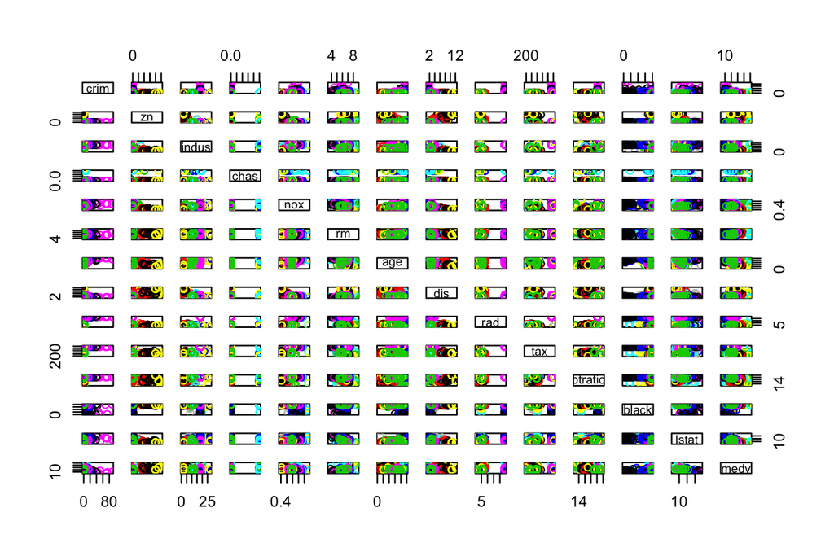

```r
# k-means clustering
km <-kmeans(dist_eu, centers = 15)

# plot the Boston dataset with clusters
pairs(Boston, col = km$cluster)
```

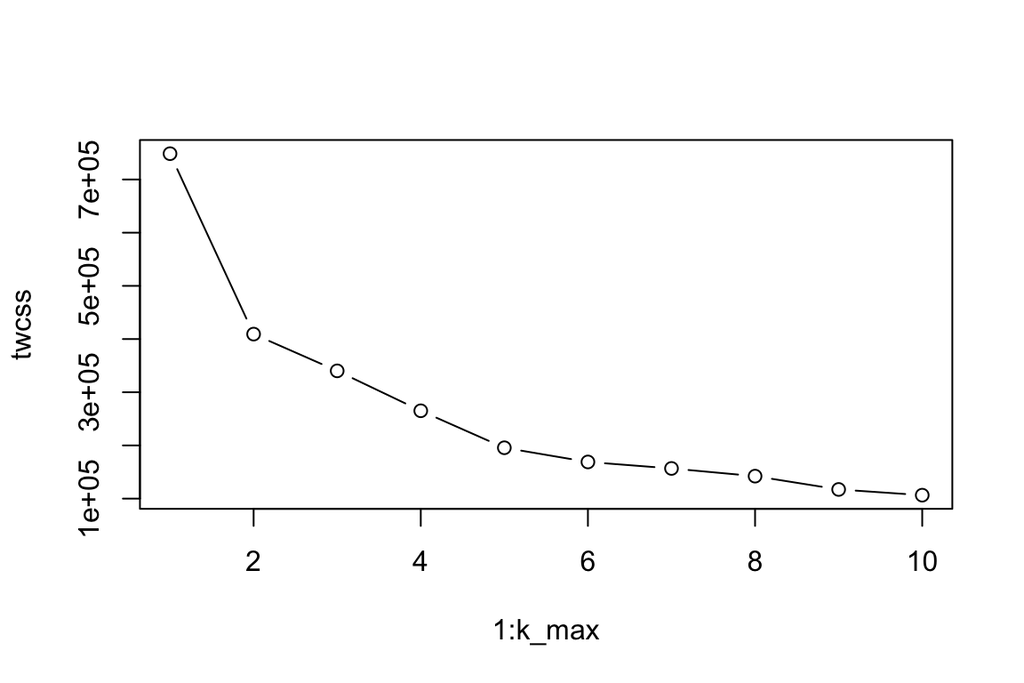

```r
# determine the number of clusters
set.seed(123)
k_max <- 10

# calculate the total within sum of squares
twcss <- sapply(1:k_max, function(k){kmeans(dist_eu, k)$tot.withinss})

# visualize the results
plot(1:k_max, twcss, type='b')
```

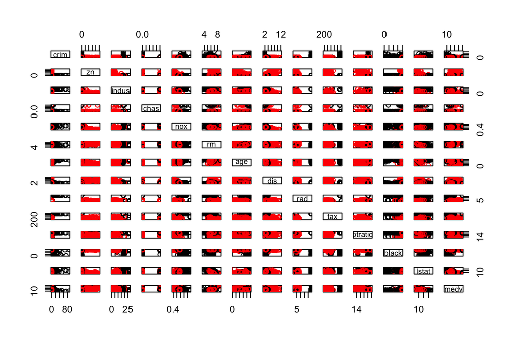

```r
# k-means clustering
#### After calculating total within sum of squares and plotting it, sharpest drop is between 1 and 2, so 2 is probably the optimal cluster amount.
km <-kmeans(dist_eu, centers = 2)

# plot the Boston dataset with clusters
pairs(Boston, col = km$cluster)
```

##### It seems that most of the times the black and red data points separate from each other and are rarely mixed. In some plots a clear pattern can be seen, such as plot between tax and crim.